# White Wine Quality Analysis by Vijayasarathi

Level of Chlorides

```r
#qplot(chlorides, data = whitewine, binwidth = 0.01) +
 #   scale_x_log10(breaks = seq(min(whitewine$chlorides), max(whitewine$chlorides), 0.1))

summary(whitewine$chlorides)
```

```
##    Min. 1st Qu.  Median    Mean 3rd Qu.    Max.
## 0.00900 0.03600 0.04300 0.04577 0.05000 0.34600
```

Multi variable analysis :

Quality vs Density:

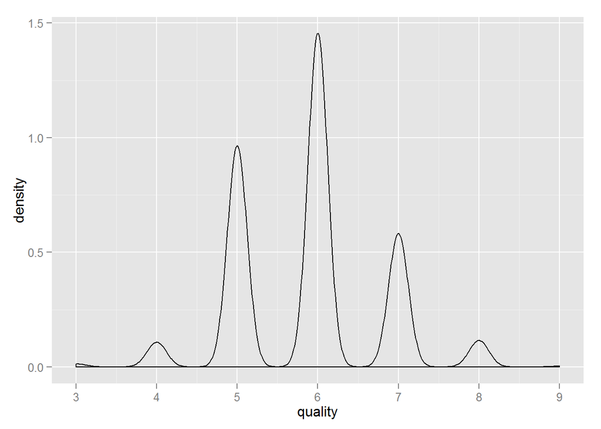

```r
qplot(quality, data = whitewine, binwidth = 1,  geom = "density") +
    scale_x_continuous(breaks = seq(3, 9, 1))
```

peak is at the qualtiy value of 6. it also carries high mark when the quality is 5 or 7.

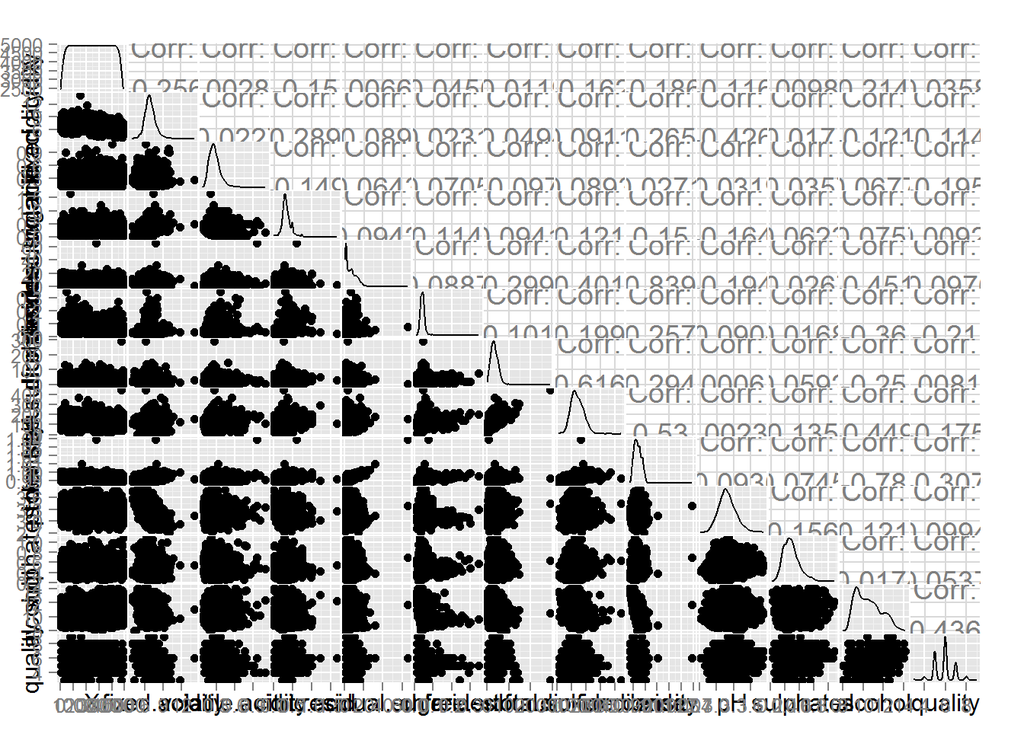

```r
ggpairs(whitewine)
```

We can see some correlation in pairs like:

alcohol vs. density fixed.acidity vs. density residual.sugar vs total.sulfur.dioxide residual.sugar vs. density residual.sugar vs. alcohol chlorides vs. density chlorides vs. sulphates quality vs. alcohol

Compare objective parameters of wines

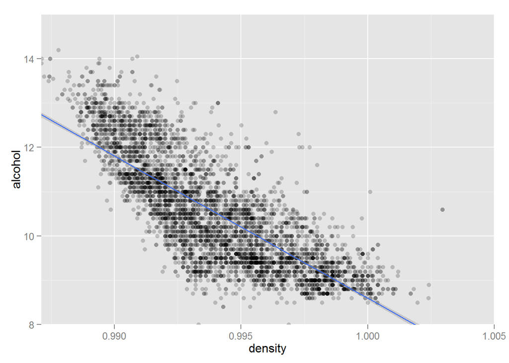

```r
#function to use the ggplot
f <- function(dataset, x, y,  opts=NULL) {
  ggplot(dataset, aes_string(x = x, y = y)) +
   geom_point(alpha = 1/5, position = position_jitter(h = 0), size = 2) +
   geom_smooth(method = 'lm')
}

# density vs. alcohol plot
p <- f(whitewine, "density", "alcohol")
p + coord_cartesian(xlim=c(min(whitewine$density),1.005), ylim=c(8,15))
```

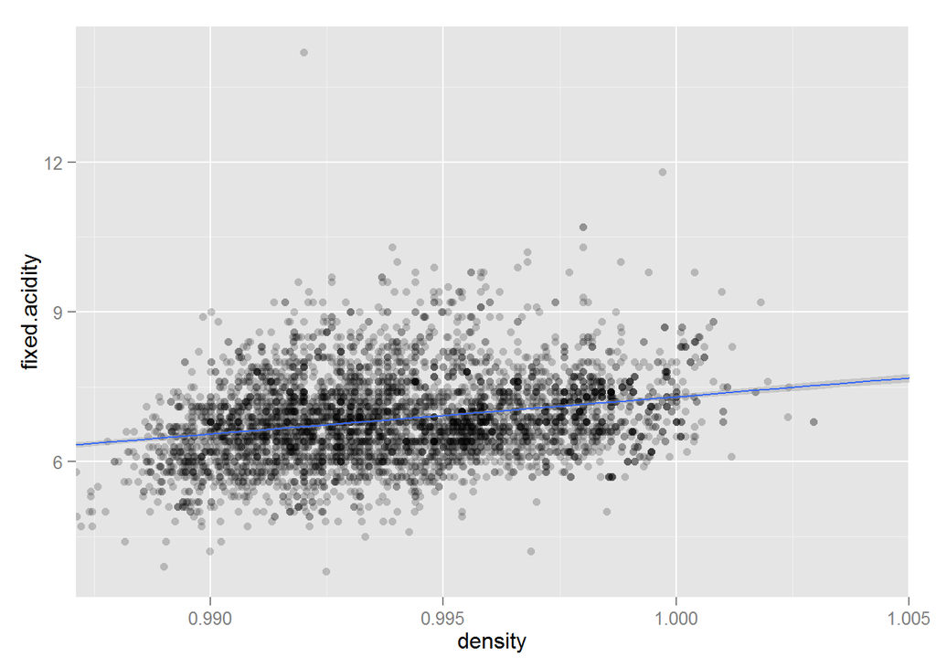

```r
# density vs. fixed.acidity plot
p <- f(whitewine, "density", "fixed.acidity")
p + coord_cartesian(xlim=c(min(whitewine$density),1.005))
```

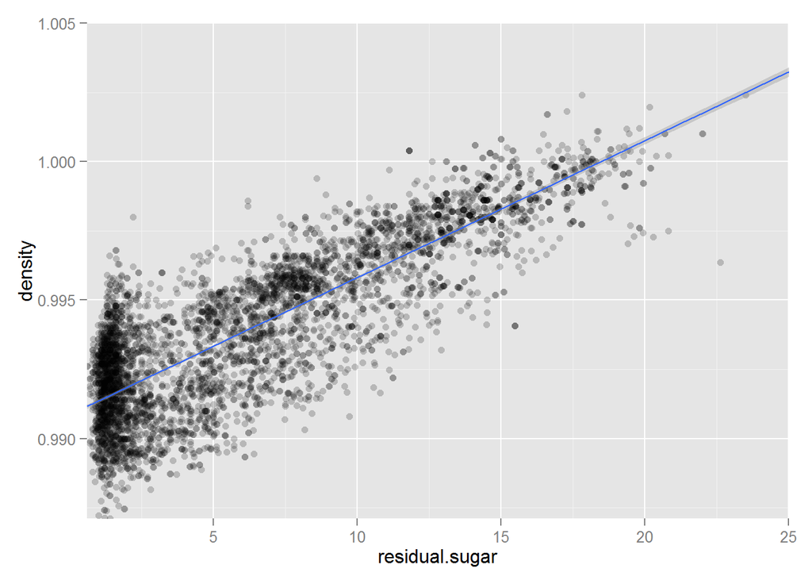

```r
# residual.sugar vs. density
p <- f(whitewine, "residual.sugar", "density")
p + coord_cartesian(xlim=c(min(whitewine$residual.sugar),25),
                    ylim=c(min(whitewine$density), 1.005))
```

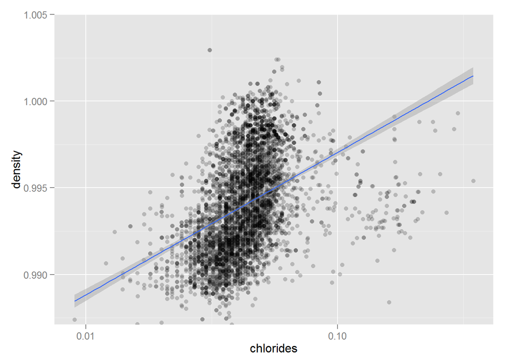

```r
# chlorides vs. density
p <- f(whitewine, "chlorides", "density")
p + scale_x_log10() +
    coord_cartesian(ylim=c(min(whitewine$density), 1.005))
```

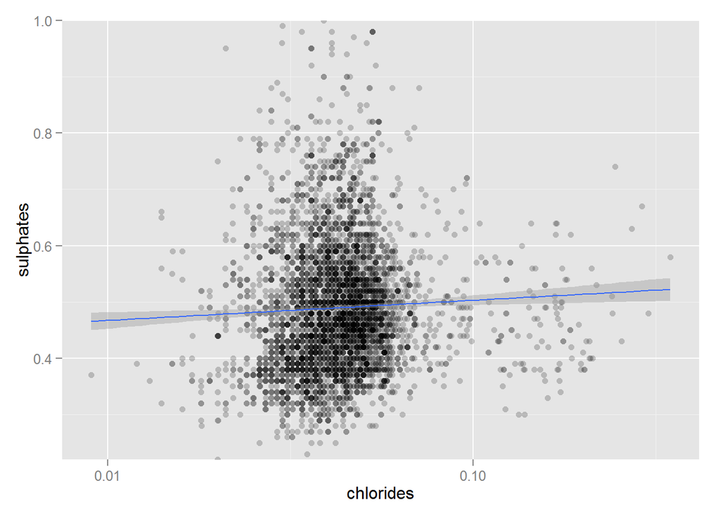

```r
# chlorides vs. sulphates
p <- f(whitewine, "chlorides", "sulphates")
p + scale_x_log10() +
    coord_cartesian(ylim=c(min(whitewine$sulphates), 1))
```

from the above plots it looks like the correlation varies significantly based on the variables and measure we use for analysis.